# User Guide

- Introduction
- Creating a ScalaTion Notebook
- Using the ScalaTion Big Data Framework
- Basic Plotting
  - `::plotv`
    - Arguments
    - Example
  - `::plotm`
    - Arguments
    - Example
- Formatters

## Introduction

The **Scalation Kernel** project provides a lightweight Scala + Scalation kernel for Jupyter notebooks.

**ScalaTion** serves a testbed for exploring a modeling continuum that includes Analytics, Simulation and Optimization. ScalaTion provides comprehensive support for Discrete-Event Simulation (DES) and an easy to use framework for Big Data Analytics. As optimization techniques are used in analytics and for simulation optimization, many optimization algorithms are also provided.

## Creating a ScalaTion Notebook

The *New* menu in Jupyter should show an option to create a ScalaTion notebook using the installed kernel.

[figure not shown]

## Using the ScalaTion Big Data Framework

Coming soon.

## Basic Plotting

Currently, there are two functions which facilitate the plotting of ScalaTion vectors and matrices. We will discuss them one by one and understand their use cases.

### `::plotv`

The `::plotv` command plots one or more ScalaTion vectors.

```
::plotv  [--title TITLE] [--xlabel XLABEL] [--ylabel YLABEL] V [V ...]
```

#### Arguments

- `V` - a ScalaTion vector
- `--title TITLE` - plot title
- `--xlabel XLABEL` - x-axis label
- `--ylabel YLABEL` - y-axis label
- `--bar` - creates a bar graph
- `--xkcd` - draws a graph in the art style of [xkcd](https://xkcd.com/) (Default: Line graph)
- `--scatter` - creates a scatter plot

#### Example

The following example plots a vector representing the function `y = x + e` where `e` is i.i.d. according to Normal distribution with mean zero and variance ten:

```
import scalation.linalgebra.VectorD
import scalation.random.Normal
e: scalation.random.Normal = Normal(0.0,10.0,0)
v: scalation.linalgebra.VectorD = VectorD(4.57987,	3.22270,	-0.511910,	3.95842,	3.10748,	2.39073,	6.08916,	8.29032,	7.72306,	6.92238,	5.75901,	12.9162,	13.9683,	15.1719,	15.4534,	14.5528,	14.2921,	9.13865,	26.4205,	19.0885,	18.3325,	18.8580,	21.2818,	23.0490,	25.2731,	22.5089,	25.4117,	29.5703,	29.4…
```

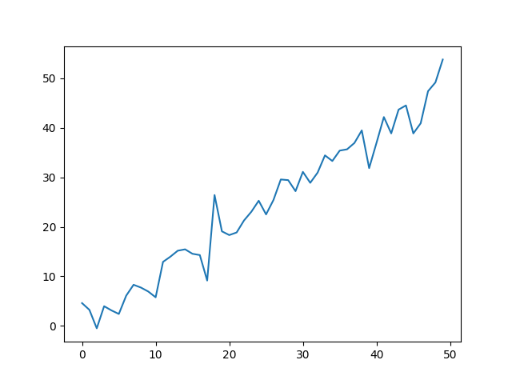

```scala
import scalation.linalgebra.VectorD
import scalation.random.Normal
val e = Normal(0, 10)
val v = VectorD((0 until 50).map(_ + e.gen))
::plotv v
```

### `::plotm`

The `::plotm` command plots columns from one or more ScalaTion matrices.

```
::plotm  [--title TITLE] [--xlabel XLABEL] [--ylabel YLABEL] M [M ...]
```

#### Arguments

- `M` - a ScalaTion matrix
- `--title TITLE` - plot title
- `--xlabel XLABEL` - x-axis label
- `--ylabel YLABEL` - y-axis label

#### Example

The following example plots a matrix where each column represents the function `y_j = x + (100 * j) + e` where `e` is i.i.d. according to Normal distribution with mean zero and variance one hundred:

```
import scalation.linalgebra.{MatrixD, VectorD}
import scalation.random.Normal
e: scalation.random.Normal = Normal(0.0,100.0,0)
y: (j: Int)(x: Double)Double
makeCol: (j: Int)scalation.linalgebra.VectorD
m: scalation.linalgebra.MatrixD =

MatrixD(14.4828,	95.6089,	195.867,	287.147,
	8.02879,	101.439,	193.935,	295.586,
	-5.94336,	94.1552,	194.919,	302.973,
	6.03078,	103.659,	197.814,	295.666,
	1.17759,	95.7281,	203.725,	305.086,
	-3.25125,	116.429,	210.714,	328.023,
	6.28194,	89.2866,	193.700,	297.915,
	11.0803,	99.8665,	208.962,	290.913,
	7.12423,	100.527,	208.541,	288.699,
	2.42999,	117.392,	202.366,	308.119,
	-3.41117,	122.083,	211.318,	319.954,
	17.0597,	112.011,	214.133,	301.531,
	18.2244,	118.278,	214.938,	321.389,
	19.8682,	115.900,	219.951,	304.054,
	18.5961,	108.506,	213.972,	316.258,
	13.5860,	125.477,	238.057,	330.457,
	10.5990,	117.434,	226.134,	315.290,
	-7.85977,	131.353,	207.279,	315.335,
	44.6280,	123.159,	232.774,	320.246,
	19.2799,	121.750,	226.759,	323.328,
	14.7270,	1...
```

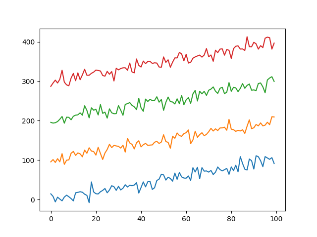

```scala
import scalation.linalgebra.{MatrixD, VectorD}
import scalation.random.Normal
val e = Normal(0, 100)
def y(j: Int)(x: Double) = x + (100 * j) + e.gen
def makeCol(j: Int) = VectorD((0 until 100).map(y(j)(_)))
val m = MatrixD((0 to 3).map(makeCol(_)))
::plotm m
```

## Formatters

Coming soon.

Copyright (c) 2017 Michael E. Cotterell and the University of Georgia. This software is free and open source under an [MIT License](https://github.com/scalation/scalation_kernel/blob/master/LICENSE.md). The content and opinions expressed on this Web page do not necessarily reflect the views of nor are they endorsed by the University of Georgia or the University System of Georgia.